# LMM Analysis Fixation Duration 0-2sec

Daniel Backhaus

september 2020

# Load data

Define DV

```
## # A tibble: 6 x 22
##   VP    trial Img   cond  fd[,1] nthpres DV[,1] DV_org[,1]   noise FT
##   <fct> <dbl> <fct> <fct>  <dbl> <fct>    <dbl>      <dbl>   <dbl> <fct>
## 1 1         1 9     1       200  1         213.       200   13.0   Free…
## 2 1         1 9     1       375  1         376.       375    0.588 Free…
## 3 1         1 9     1       392. 1         393.       392.   1.08  Free…
## 4 1         1 9     1       283. 1         298.       283.  14.3   Free…
## 5 1         1 9     1       133. 1         137.       133.   3.84  Free…
## 6 1         2 7     1       275  1         264.       275  -10.5   Free…
## # … with 12 more variables: FB <fct>, Factor <fct>, DV_log[,1] <dbl>,
## #   DV_reci[,1] <dbl>, FT.e <dbl>, FT.t <dbl>, FB.e <dbl>, FB.t <dbl>,
## #   GM <dbl>, n.FT <dbl>, n.FB <dbl>, n.FAB <dbl>
```

```
##        VP           trial            Img       cond           fd.V1
##  25     : 368   Min.   : 1.00   14     : 322   1:2066   Min.   : 33.3333
##  23     : 364   1st Qu.:16.00   7      : 306   2:2074   1st Qu.:158.3333
##  17     : 357   Median :32.00   24     : 302   3:2265   Median :216.6667
##  5      : 353   Mean   :31.14   1      : 301   4:2192   Mean   :255.4292
##  1      : 350   3rd Qu.:46.00   11     : 300            3rd Qu.:308.3333
##  8      : 341   Max.   :60.00   30     : 300            Max.   :991.6667
##  (Other):6464                   (Other):6766
##  nthpres        DV.V1            DV_org.V1          noise
##  1:4140   Min.   : 19.0459   Min.   : 33.3333   Min.   :-32.04433
##  2:4457   1st Qu.:155.3765   1st Qu.:158.3333   1st Qu.: -5.49066
##           Median :214.6956   Median :216.6667   Median : -0.02162
##           Mean   :255.4658   Mean   :255.4292   Mean   :  0.03656
##           3rd Qu.:307.7970   3rd Qu.:308.3333   3rd Qu.:  5.70258
##           Max.   :999.5893   Max.   :991.6667   Max.   : 32.06473
##
##            FT                     FB
##  FreeViewing:4140   SittingChinrest:4331
##  GuessTime  :4457   Standing       :4266
##
##
##
##
##
##                          Factor         DV_log.V1
##  FreeViewing_SittingChinrest:2066   Min.   :2.946854
##  FreeViewing_Standing       :2074   1st Qu.:5.045851
##  GuessTime_SittingChinrest  :2265   Median :5.369221
##  GuessTime_Standing         :2192   Mean   :5.404842
##                                     3rd Qu.:5.729440
##                                     Max.   :6.907345
##
##       DV_reci.V1           FT.e               FT.t
##  Min.   :0.00100041   Min.   :-0.50000   Min.   :0.0000
##  1st Qu.:0.00324890   1st Qu.:-0.50000   1st Qu.:0.0000
##  Median :0.00465776   Median : 0.50000   Median :1.0000
##  Mean   :0.00512411   Mean   : 0.01844   Mean   :0.5184
##  3rd Qu.:0.00643598   3rd Qu.: 0.50000   3rd Qu.:1.0000
##  Max.   :0.05250464   Max.   : 0.50000   Max.   :1.0000
##
##       FB.e               FB.t              GM         n.FT
##  Min.   :-0.50000   Min.   :0.0000   Min.   :1   Min.   :-0.50000
##  1st Qu.:-0.50000   1st Qu.:0.0000   1st Qu.:1   1st Qu.:-0.50000
##  Median :-0.50000   Median :0.0000   Median :1   Median : 0.50000
##  Mean   :-0.00378   Mean   :0.4962   Mean   :1   Mean   : 0.01844
##  3rd Qu.: 0.50000   3rd Qu.:1.0000   3rd Qu.:1   3rd Qu.: 0.50000
##  Max.   : 0.50000   Max.   :1.0000   Max.   :1   Max.   : 0.50000
##
##       n.FB              n.FAB
##  Min.   :-0.50000   Min.   :-0.250000
##  1st Qu.:-0.50000   1st Qu.:-0.250000
##  Median :-0.50000   Median :-0.250000
##  Mean   :-0.00378   Mean   :-0.002355
##  3rd Qu.: 0.50000   3rd Qu.: 0.250000
##  Max.   : 0.50000   Max.   : 0.250000
##
```

```
## Observations: 8,597
## Variables: 22
## $ VP      <fct> 1, 1, 1, 1, 1, 1, 1, 1, 1, 1, 1, 1, 1, 1, 1, 1, 1, 1, 1,…
## $ trial   <dbl> 1, 1, 1, 1, 1, 2, 2, 2, 2, 2, 2, 3, 3, 3, 3, 3, 3, 3, 4,…
## $ Img     <fct> 9, 9, 9, 9, 9, 7, 7, 7, 7, 7, 7, 4, 4, 4, 4, 4, 4, 4, 3,…
## $ cond    <fct> 1, 1, 1, 1, 1, 1, 1, 1, 1, 1, 1, 1, 1, 1, 1, 1, 1, 1, 1,…
## $ fd      <dbl[,1]> <matrix[25 x 1]>
## $ nthpres <fct> 1, 1, 1, 1, 1, 1, 1, 1, 1, 1, 1, 1, 1, 1, 1, 1, 1, 1, 1,…
## $ DV      <dbl[,1]> <matrix[25 x 1]>
## $ DV_org  <dbl[,1]> <matrix[25 x 1]>
## $ noise   <dbl> 12.9892360, 0.5875699, 1.0773978, 14.2922082, 3.8409684,…
## $ FT      <fct> FreeViewing, FreeViewing, FreeViewing, FreeViewing, Free…
## $ FB      <fct> SittingChinrest, SittingChinrest, SittingChinrest, Sitti…
## $ Factor  <fct> FreeViewing_SittingChinrest, FreeViewing_SittingChinrest…
## $ DV_log  <dbl[,1]> <matrix[25 x 1]>
## $ DV_reci <dbl[,1]> <matrix[25 x 1]>
## $ FT.e    <dbl> -0.5, -0.5, -0.5, -0.5, -0.5, -0.5, -0.5, -0.5, -0.5, -0…
## $ FT.t    <dbl> 0, 0, 0, 0, 0, 0, 0, 0, 0, 0, 0, 0, 0, 0, 0, 0, 0, 0, 0,…
## $ FB.e    <dbl> -0.5, -0.5, -0.5, -0.5, -0.5, -0.5, -0.5, -0.5, -0.5, -0…
## $ FB.t    <dbl> 0, 0, 0, 0, 0, 0, 0, 0, 0, 0, 0, 0, 0, 0, 0, 0, 0, 0, 0,…
## $ GM      <dbl> 1, 1, 1, 1, 1, 1, 1, 1, 1, 1, 1, 1, 1, 1, 1, 1, 1, 1, 1,…
## $ n.FT    <dbl> -0.5, -0.5, -0.5, -0.5, -0.5, -0.5, -0.5, -0.5, -0.5, -0…
## $ n.FB    <dbl> -0.5, -0.5, -0.5, -0.5, -0.5, -0.5, -0.5, -0.5, -0.5, -0…
## $ n.FAB   <dbl> 0.25, 0.25, 0.25, 0.25, 0.25, 0.25, 0.25, 0.25, 0.25, 0.…
```

# Check DV Distribution

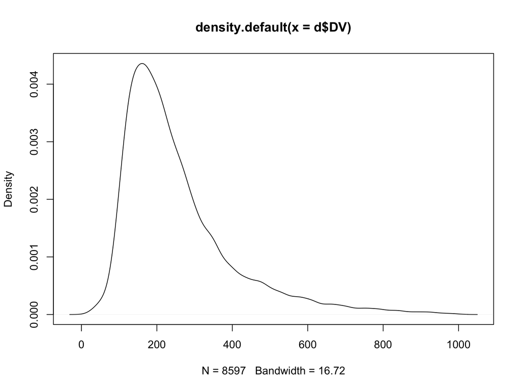

```r
plot(density(d$DV))
```

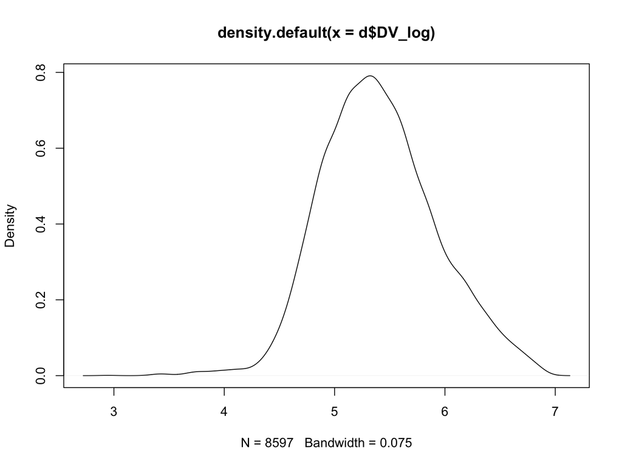

```r
plot(density(d$DV_log))
```

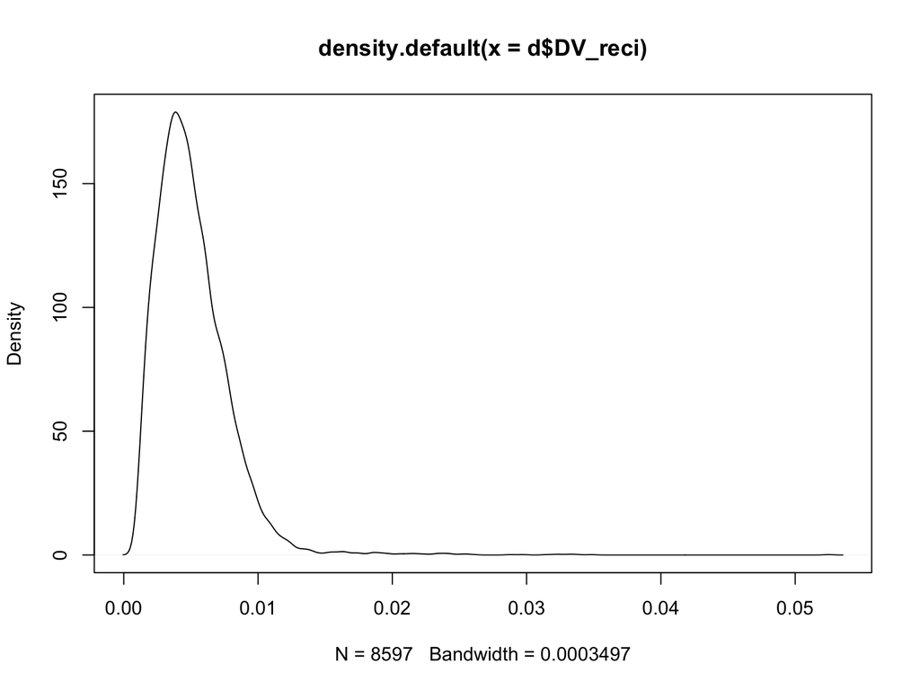

```r
plot(density(d$DV_reci))
```

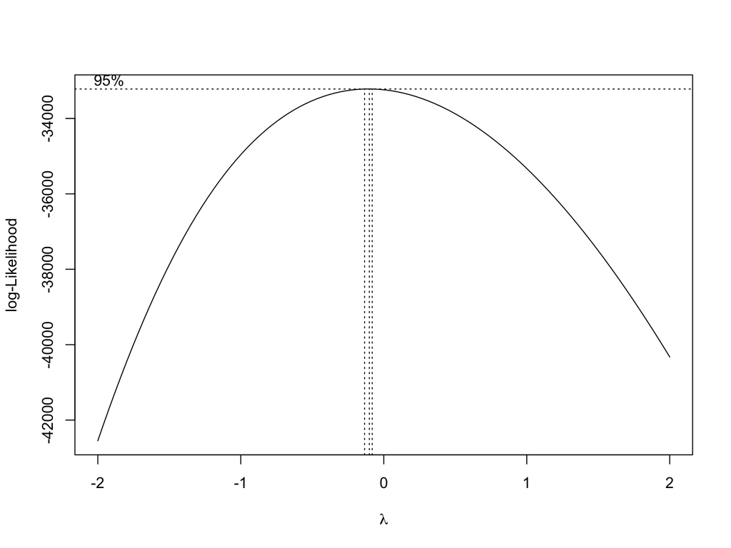

```r
boxcox(DV~ Img, data=d)
```

Transformation required?

0 = log

-1 = reciproc

1 = none

```r
d <- d %>%
  mutate(DV=DV_log)
labelDV<-sprintf("Log Fixation Duration 0-2sec")
```

plot Outlier

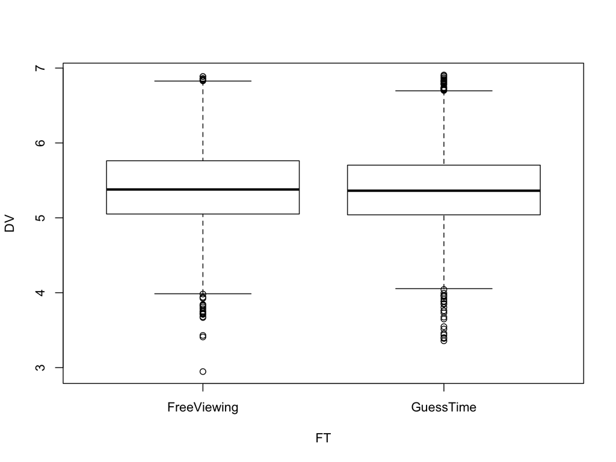

```r
plot(DV~FT, data=d)
```

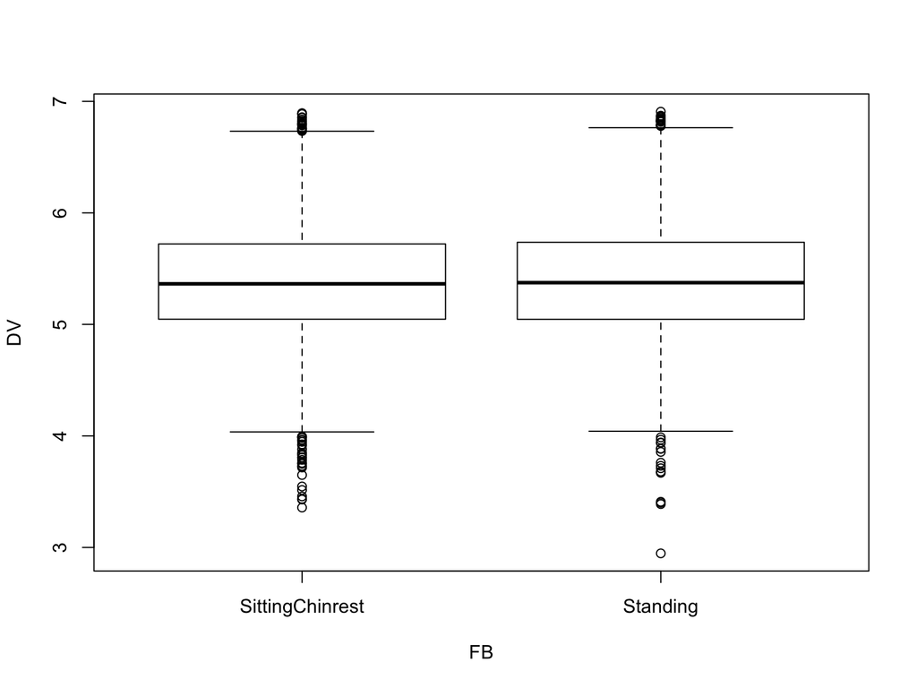

```r
plot(DV~FB, data=d)
```

# Descriptive statistics

Means

```r
FB_M_SD <- d %>%
              group_by(FB, FB.e, FB.t) %>%
              summarise(N = n(),
                        M_DV = mean(DV),
                        SD_DV = sd(DV))

FB_M_SD
```

```
## # A tibble: 2 x 6
## # Groups:   FB, FB.e [2]
##   FB               FB.e  FB.t     N  M_DV SD_DV
##   <fct>           <dbl> <dbl> <int> <dbl> <dbl>
## 1 SittingChinrest  -0.5     0  4331  5.40 0.519
## 2 Standing          0.5     1  4266  5.41 0.517
```

```r
FT_M_SD <- d %>%
              group_by(FT, FT.e, FT.t) %>%
              summarise(N = n(),
                        M_DV = mean(DV),
                        SD_DV = sd(DV))

FT_M_SD
```

```
## # A tibble: 2 x 6
## # Groups:   FT, FT.e [2]
##   FT           FT.e  FT.t     N  M_DV SD_DV
##   <fct>       <dbl> <dbl> <int> <dbl> <dbl>
## 1 FreeViewing  -0.5     0  4140  5.42 0.534
## 2 GuessTime     0.5     1  4457  5.39 0.502
```

# Fit maximal LMM

## Modelselection

```r
#lmm.max.fac <- lmer(DV ~ 1+FT+FB+FT:FB + (1+FT+FB+FT:FB | VP) + (1+FT+FB+FT:FB | Img), data=d, REML=FALSE)#sf
#lmm.max.num <- lmer(DV ~ 1+n.FT+n.FB+n.FAB + (1+n.FT+n.FB+n.FAB | VP) + (1+n.FT+n.FB+n.FAB | Img), data=d, #REML=FALSE)#sf
#
#anova(lmm.max.fac, lmm.max.num) #same
##remove correlations
#lmm1<-lmer(DV ~ 1+n.FT+n.FB+n.FAB + (1+n.FT+n.FB+n.FAB || VP) + (1+n.FT+n.FB+n.FAB || Img), data=d, #REML=FALSE) #sf
#summary(lmm1)
#
## remove least varying parameter
##(FB|Img)
#lmm2<-lmer(DV ~ 1+n.FT+n.FB+n.FAB + (1+n.FT+n.FB+n.FAB || VP) + (1+n.FT+n.FAB || Img), data=d, REML=FALSE)#nc
#summary(lmm2)
#
## (FB|VP)
#lmm3<-lmer(DV ~ 1+n.FT+n.FB+n.FAB + (1+n.FT+n.FAB || VP) + (1+n.FT+n.FAB || Img), data=d, REML=FALSE)#nc
#summary(lmm3)
#
## (FAB|Img)
#lmm4<-lmer(DV ~ 1+n.FT+n.FB+n.FAB + (1+n.FT+n.FAB || VP) + (1+n.FT|| Img), data=d, REML=FALSE)#nc
#summary(lmm4)
#
## (FAB|VP)
#lmm5<-lmer(DV ~ 1+n.FT+n.FB+n.FAB + (1+n.FT || VP) + (1+n.FT|| Img), data=d, REML=FALSE)#converge
#summary(lmm5)
#
##try smaler model
#lmm6a<-lmer(DV ~ 1+n.FT+n.FB+n.FAB + (1 +n.FT || VP) + (1 | Img), data=d, REML=FALSE)#converge
#lmm6b<-lmer(DV ~ 1+n.FT+n.FB+n.FAB + (1 | VP) + (1 +n.FT|| Img), data=d, REML=FALSE)#converge
lmm6c<-lmer(DV ~ 1+n.FT+n.FB+n.FAB + (1 | VP) + (1 | Img), data=d, REML=FALSE)#converge
#
#anova(lmm5,lmm6a)
#anova(lmm5,lmm6b)
#anova(lmm5,lmm6c)
#
#summary(lmm6c)
#
##choose smallest to held comparability for other time selections (other than 0 - 200ms)

lmm<-lmm6c

summary(lmm)
```

```
## Linear mixed model fit by maximum likelihood . t-tests use
##   Satterthwaite's method [lmerModLmerTest]
## Formula: DV ~ 1 + n.FT + n.FB + n.FAB + (1 | VP) + (1 | Img)
##    Data: d
##
##      AIC      BIC   logLik deviance df.resid
##  12956.0  13005.4  -6471.0  12942.0     8590
##
## Scaled residuals:
##     Min      1Q  Median      3Q     Max
## -4.7082 -0.6882 -0.0629  0.6158  3.0697
##
## Random effects:
##  Groups   Name        Variance Std.Dev.
##  Img      (Intercept) 0.001892 0.0435
##  VP       (Intercept) 0.004928 0.0702
##  Residual             0.261220 0.5111
## Number of obs: 8597, groups:  Img, 30; VP, 27
##
## Fixed effects:
##               Estimate Std. Error         df t value Pr(>|t|)
## (Intercept)    5.40983    0.01662   37.61257 325.493  < 2e-16 ***
## n.FT          -0.03710    0.01106 8558.77256  -3.355 0.000797 ***
## n.FB           0.00689    0.01111 8542.45419   0.620 0.535353
## n.FAB          0.03358    0.02221 8557.39397   1.512 0.130624
## ---
## Signif. codes:  0 '***' 0.001 '**' 0.01 '*' 0.05 '.' 0.1 ' ' 1
##
## Correlation of Fixed Effects:
##       (Intr) n.FT   n.FB
## n.FT  -0.013
## n.FB   0.002  0.008
## n.FAB  0.003  0.007 -0.039
```

```r
summary(rePCA(lmm))
```

```
## $Img
## Importance of components:
##                           [,1]
## Standard deviation     0.08511
## Proportion of Variance 1.00000
## Cumulative Proportion  1.00000
##
## $VP
## Importance of components:
##                          [,1]
## Standard deviation     0.1373
## Proportion of Variance 1.0000
## Cumulative Proportion  1.0000
```

```r
print(summary(lmm), corr=FALSE)
```

```
## Linear mixed model fit by maximum likelihood . t-tests use
##   Satterthwaite's method [lmerModLmerTest]
## Formula: DV ~ 1 + n.FT + n.FB + n.FAB + (1 | VP) + (1 | Img)
##    Data: d
##
##      AIC      BIC   logLik deviance df.resid
##  12956.0  13005.4  -6471.0  12942.0     8590
##
## Scaled residuals:
##     Min      1Q  Median      3Q     Max
## -4.7082 -0.6882 -0.0629  0.6158  3.0697
##
## Random effects:
##  Groups   Name        Variance Std.Dev.
##  Img      (Intercept) 0.001892 0.0435
##  VP       (Intercept) 0.004928 0.0702
##  Residual             0.261220 0.5111
## Number of obs: 8597, groups:  Img, 30; VP, 27
##
## Fixed effects:
##               Estimate Std. Error         df t value Pr(>|t|)
## (Intercept)    5.40983    0.01662   37.61257 325.493  < 2e-16 ***
## n.FT          -0.03710    0.01106 8558.77256  -3.355 0.000797 ***
## n.FB           0.00689    0.01111 8542.45419   0.620 0.535353
## n.FAB          0.03358    0.02221 8557.39397   1.512 0.130624
## ---
## Signif. codes:  0 '***' 0.001 '**' 0.01 '*' 0.05 '.' 0.1 ' ' 1
```

## Check random effects structure

```r
summary(rePCA(lmm))
```

```
## $Img
## Importance of components:
##                           [,1]
## Standard deviation     0.08511
## Proportion of Variance 1.00000
## Cumulative Proportion  1.00000
##
## $VP
## Importance of components:
##                          [,1]
## Standard deviation     0.1373
## Proportion of Variance 1.0000
## Cumulative Proportion  1.0000
```

## Check residuals - Base R

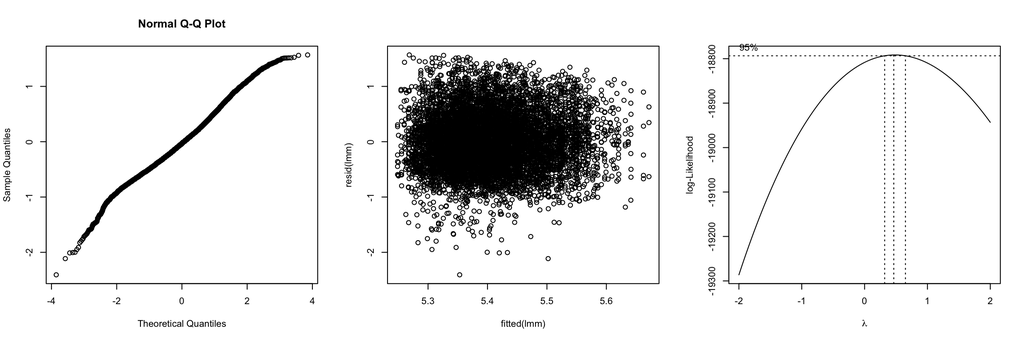

```r
par(mfcol=c(1,3))

qqnorm(resid(lmm))

plot(fitted(lmm), resid(lmm))

simdat_subset <- subset(d, DV > 0)
try(boxcox(DV ~ 1+n.FT+n.FB+n.FAB, data=simdat_subset))
```

```r
par(mfcol=c(1,1))
```

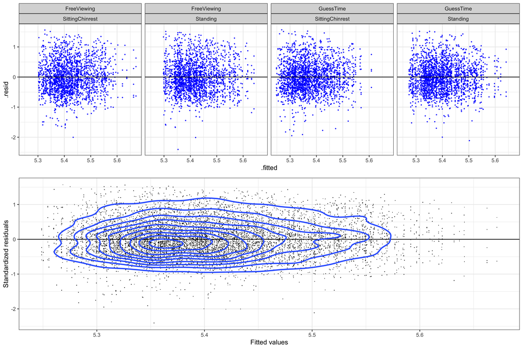

```r
simdat <- fortify.merMod(model=lmm, data = d)

p_lmm_res1 <- ggplot(simdat, aes(.fitted,.resid)) + geom_point(colour="blue", size=.3) +
                 facet_grid( ~ FT*FB) + geom_hline(yintercept=0) + theme_bw()

p_lmm_res2 <- ggplot(simdat, aes(.fitted, .resid)) +
                 geom_point(shape=I(".")) +
                 xlab("Fitted values") + ylab("Standardized residuals") + theme_bw() +
                 geom_hline(yintercept=0) + geom_density2d(size=1)  #+ geom_hex()

# Plot
grid.arrange(p_lmm_res1, p_lmm_res2, nrow=2)
```

# rmMRA, effect correlations, factor correlations, rmAOV

## Subjects rmMRA, effect correlations, factor correlations, rmAOV

## Repeated-measures multiple regression (rmMRA) - subjects

These tests represent *a priori* contrasts.

```r
# Fit rmMRA
rmMRA_coef_subj <- d %>%
                   split(.$VP) %>%
                   map(~ lm(DV ~ 1+FT+FB+FT:FB, .)) %>%
                   map_dfr( ~ as.data.frame(t(as.matrix(coef(.)))))
names(rmMRA_coef_subj) <- c("Intercept", "GuessTime-FreeViewing", "Standing-SittingChinrest", "InteractionFT:FB")


# Fixed effects (w/ tidyverse)
tab_Est_SE_subj <- rmMRA_coef_subj %>%
                   rownames_to_column("VP") %>%
                   gather(key = "Coeff", value = "value", -VP, factor_key = TRUE) %>%
                   group_by(Coeff) %>%
                   summarise(Est = mean(value), SE = sd(value), t = Est/SE)
tab_Est_SE_subj
```

```
## # A tibble: 4 x 4
##   Coeff                        Est     SE      t
##   <fct>                      <dbl>  <dbl>  <dbl>
## 1 Intercept                 5.41   0.0775 69.9
## 2 GuessTime-FreeViewing    -0.0385 0.0712 -0.541
## 3 Standing-SittingChinrest  0.0126 0.0602  0.209
## 4 InteractionFT:FB          0.0255 0.119   0.214
```

## Within-subject effect correlations

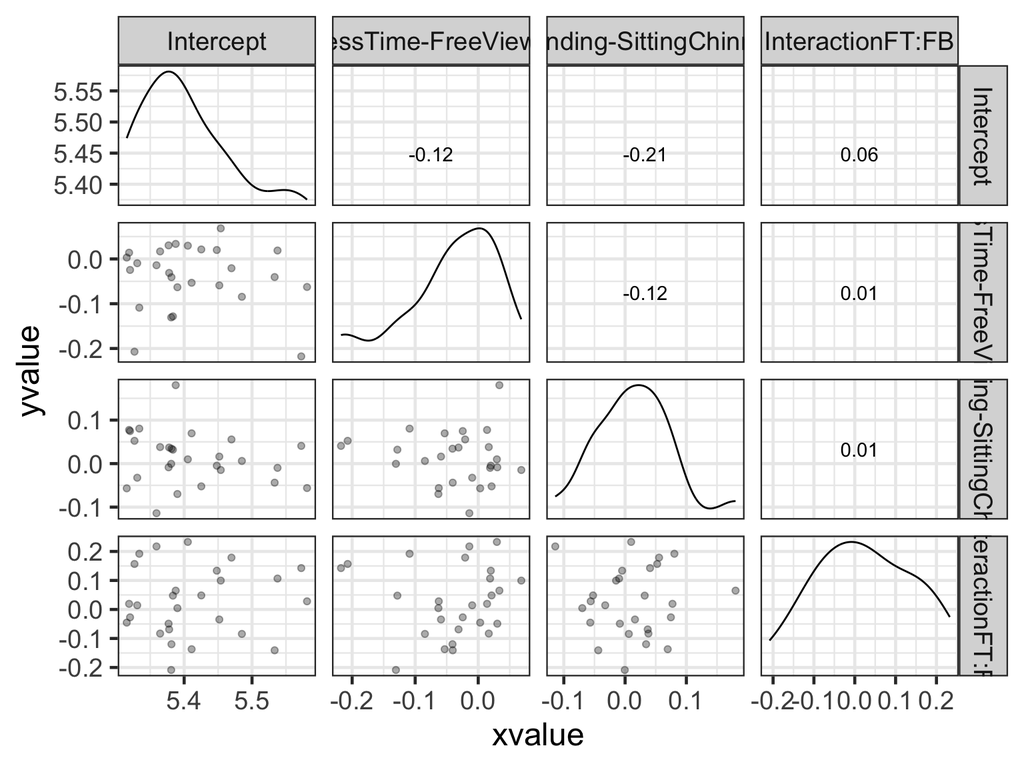

```r
# Correlations between GM and effects (CPs)
ggscatmat(rmMRA_coef_subj, columns = 1:4, alpha = 1/3) +
  theme_bw(base_size=18)
```

## Within-subject correlations of factor levels

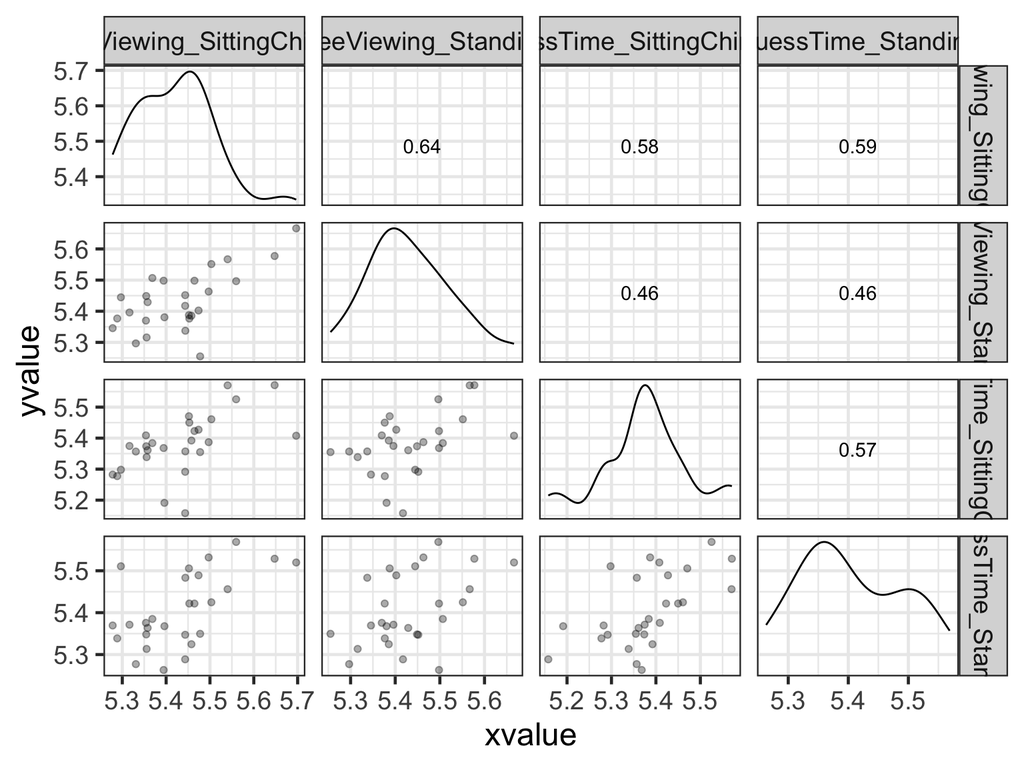

```r
# Correlations between measures (r's) -- don't confuse with CPs

simdat_subj <- d %>%
               group_by(VP, FT, FB) %>%
               summarise(N = n(), DV_subj = mean(DV), SD_subj=sd(DV)) %>%
               ungroup()


simdat_subj %>%
            dplyr::select(VP, FT,FB, DV_subj) %>%
            mutate(Factor=paste(FT, FB, sep = "_")) %>%
            dplyr::select(VP, Factor, DV_subj) %>%
            spread(Factor,DV_subj) %>%
            ggscatmat(columns = 2:5, alpha = 1/3) +
            #coord_cartesian(xlim=c(250, 550), ylim=c(250, 550)) +
            theme_bw(base_size=18)
```

## Repeated-measures Anova (rmAOV) - subjects

```r
simdat_subj <-simdat_subj %>%
              mutate(Factor=paste(FT, FB, sep = "_"))

subj_aov <- aov(DV_subj ~  Factor + Error(VP/Factor), data=simdat_subj)
coefficients(subj_aov, contrasts=list(MASS::contr.sdif))
```

```
## (Intercept) :
## (Intercept)
##    5.411961
##
## VP :
## numeric(0)
##
## VP:Factor :
##      FactorFreeViewing_Standing FactorGuessTime_SittingChinrest
##                   -0.0001421387                   -0.0512906200
##        FactorGuessTime_Standing
##                   -0.0259241588
```

## Images rmMRA, effect correlations, factor correlations, rmAOV

## Repeated-measures multiple regression (rmMRA) - Images

These tests represent *a priori* contrasts.

```r
# Fit rmMRA
rmMRA_coef_Img <- d %>%
                   split(.$Img) %>%
                   map(~ lm(DV ~ 1+FT+FB+FT:FB, .)) %>%
                   map_dfr( ~ as.data.frame(t(as.matrix(coef(.)))))
names(rmMRA_coef_Img) <- c("Intercept", "GuessTime-FreeViewing", "Standing-SittingChinrest", "InteractionFT:FB")


# Fixed effects (w/ tidyverse)
tab_Est_SE_Img <- rmMRA_coef_Img %>%
                   rownames_to_column("Img") %>%
                   gather(key = "Coeff", value = "value", -Img, factor_key = TRUE) %>%
                   group_by(Coeff) %>%
                   summarise(Est = mean(value), SE = sd(value), t = Est/SE)
tab_Est_SE_Img
```

```
## # A tibble: 4 x 4
##   Coeff                           Est     SE        t
##   <fct>                         <dbl>  <dbl>    <dbl>
## 1 Intercept                 5.41      0.0568 95.3
## 2 GuessTime-FreeViewing    -0.0383    0.0736 -0.521
## 3 Standing-SittingChinrest  0.0000773 0.0598  0.00129
## 4 InteractionFT:FB          0.0443    0.150   0.295
```

## Within-Img effect correlations

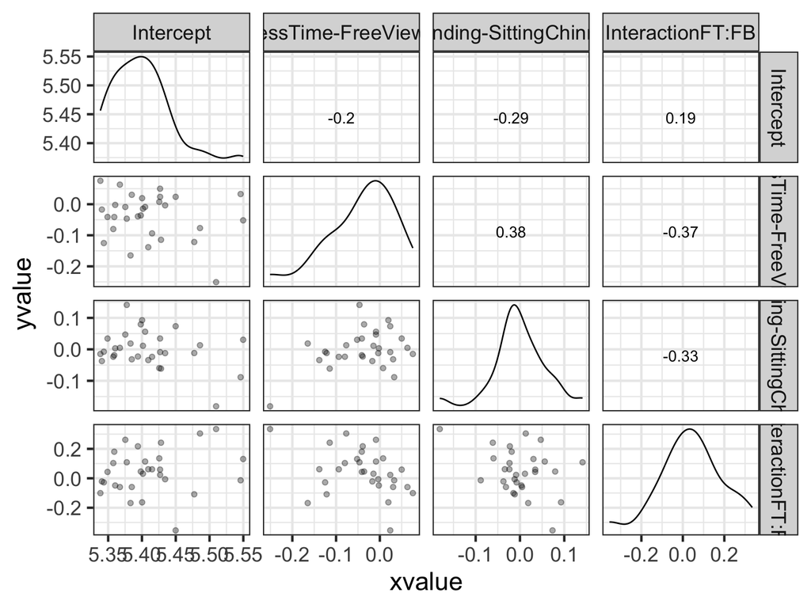

```r
# Correlations between GM and contrasts (CPs)

# Fit rmMRA
rmMRA_coef_Img <- d %>%
                   split(.$Img) %>%
                   map(~ lm(DV ~ 1+ FT+FB+FT:FB, .)) %>%
                   map_dfr( ~ as.data.frame(t(as.matrix(coef(.)))))
names(rmMRA_coef_Img) <- c("Intercept", "GuessTime-FreeViewing", "Standing-SittingChinrest", "InteractionFT:FB")

ggscatmat(rmMRA_coef_Img, columns = 1:4, alpha = 1/3) + theme_bw(base_size=18)
```

## Within-Img correlations of factor levels

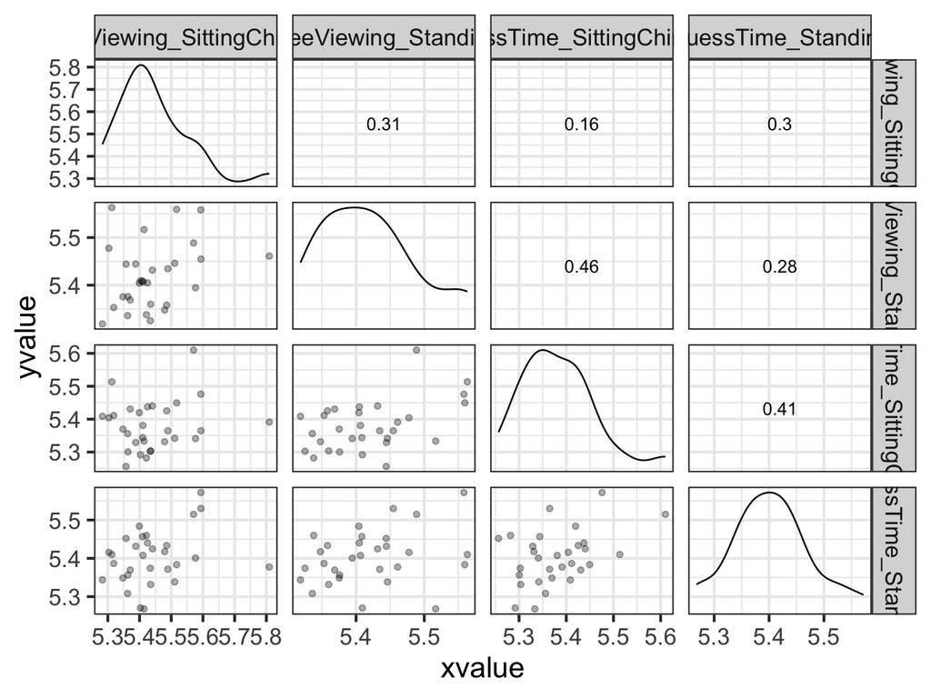

```r
# Correlations between measures (r's)
simdat_Img <- d %>%
               group_by(Img, FT, FB) %>%
               summarise(N = n(), DV_Img = mean(DV), SD_Img=sd(DV)) %>%
               ungroup()


simdat_Img %>%
            dplyr::select(Img, FT, FB, DV_Img) %>%
            mutate(Factor=paste(FT, FB, sep = "_")) %>%
            dplyr::select(Img, Factor, DV_Img) %>%
            spread(Factor, DV_Img) %>%
            ggscatmat(columns = 2:5, alpha = 1/3) +
            #coord_cartesian(xlim=c(250, 550), ylim=c(250, 550)) +
            theme_bw(base_size=18)
```

## Repeated-measures Anova (rmAOV) - Image

```r
simdat_Img <-simdat_Img %>%
              mutate(Factor=paste(FT, FB, sep = "_"))

Img_aov <- aov(DV_Img ~  Factor + Error(Img/Factor), data=simdat_Img)
coefficients(Img_aov, contrasts=list(MASS::contr.sdif))
```

```
## (Intercept) :
## (Intercept)
##    5.410665
##
## Img :
## numeric(0)
##
## Img:Factor :
##      FactorFreeViewing_Standing FactorGuessTime_SittingChinrest
##                     -0.02207012                     -0.06049450
##        FactorGuessTime_Standing
##                     -0.03826984
```

# Significance of fixed-effects (contrasts)

```r
# fixed effects
fixef(lmm)
```

```
##  (Intercept)         n.FT         n.FB        n.FAB
##  5.409829576 -0.037099611  0.006890164  0.033581769
```

```r
# profiling
#p_lmm <- profile(lmm, which="beta_")
#confint(p_lmm)

# bootstrap
#confint(lmm, parm=c("(Intercept)", "n.FT", "n.FB", "n.FAB"),
#        method="boot")

# Wald
#confint(lmm,parm=c("(Intercept)","n.FT","n.FB","n.FAB"),
#        method="Wald")
```

## Table of LMM partial effects

This table copy/pastes nicely into a Word.docx table…

```r
labels <- c("GuessTime-FreeViewing", "Standing-SittingChinrest", "InteractionFT:FB")

keep.terms <- names(fixef(lmm)[-1])

## Computing p-values via Wald-statistics approximation (treating t as Wald z).
tab_model(lmm, terms=keep.terms, pred.labels=labels,
          show.se=TRUE, show.stat=TRUE, show.ci = FALSE, string.se = "SE",
          show.re.var=FALSE, show.obs=TRUE,
          emph.p = FALSE, dv.labels=labelDV , show.icc = FALSE)
```

|  | Log Fixation Duration 0-2sec |  |  |  |
| --- | --- | --- | --- | --- |
| Predictors | Estimates | SE | Statistic | p |
| GuessTime-FreeViewing | -0.04 | 0.01 | -3.36 | 0.001 |
| Standing-SittingChinrest | 0.01 | 0.01 | 0.62 | 0.535 |
| InteractionFT:FB | 0.03 | 0.02 | 1.51 | 0.131 |
| N <sub>VP</sub> | 27 |  |  |  |
| N <sub>Img</sub> | 30 |  |  |  |
| Observations | 8597 |  |  |  |
| Marginal R<sup>2</sup> / Conditional R<sup>2</sup> | 0.002 / 0.027 |  |  |  |

```r
summary(lmm)
```

```
## Linear mixed model fit by maximum likelihood . t-tests use
##   Satterthwaite's method [lmerModLmerTest]
## Formula: DV ~ 1 + n.FT + n.FB + n.FAB + (1 | VP) + (1 | Img)
##    Data: d
##
##      AIC      BIC   logLik deviance df.resid
##  12956.0  13005.4  -6471.0  12942.0     8590
##
## Scaled residuals:
##     Min      1Q  Median      3Q     Max
## -4.7082 -0.6882 -0.0629  0.6158  3.0697
##
## Random effects:
##  Groups   Name        Variance Std.Dev.
##  Img      (Intercept) 0.001892 0.0435
##  VP       (Intercept) 0.004928 0.0702
##  Residual             0.261220 0.5111
## Number of obs: 8597, groups:  Img, 30; VP, 27
##
## Fixed effects:
##               Estimate Std. Error         df t value Pr(>|t|)
## (Intercept)    5.40983    0.01662   37.61257 325.493  < 2e-16 ***
## n.FT          -0.03710    0.01106 8558.77256  -3.355 0.000797 ***
## n.FB           0.00689    0.01111 8542.45419   0.620 0.535353
## n.FAB          0.03358    0.02221 8557.39397   1.512 0.130624
## ---
## Signif. codes:  0 '***' 0.001 '**' 0.01 '*' 0.05 '.' 0.1 ' ' 1
##
## Correlation of Fixed Effects:
##       (Intr) n.FT   n.FB
## n.FT  -0.013
## n.FB   0.002  0.008
## n.FAB  0.003  0.007 -0.039
```

## Visualize LMM partial effects (1)

We visualize the effects. There are two formats. First, we plot the coefficients as a forest plot. This is the most direct way of converting the effects into graph, because the estimates represent the effect tested. (We leave out the GM.)

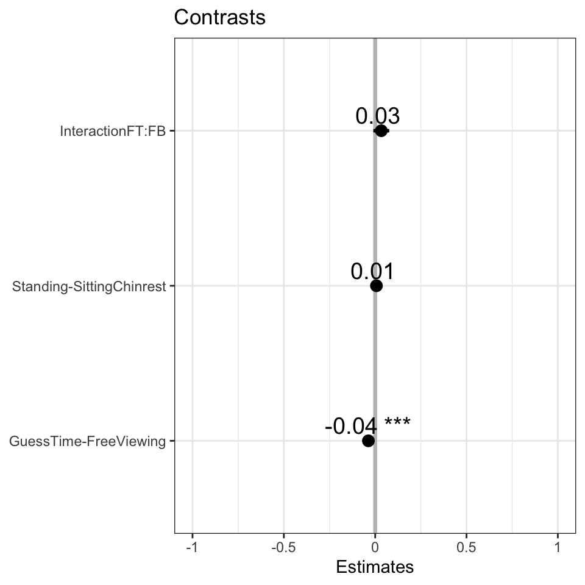

```r
plot_model(lmm, title = "Contrasts",
           terms=keep.terms,
           axis.labels = labels,
           colors = "bw", show.values = TRUE, show.p = TRUE, value.offset = .1, value.size = 5,
           dot.size = 3, line.size = 1, vline.color = "grey", width = 0) + theme_bw()
```

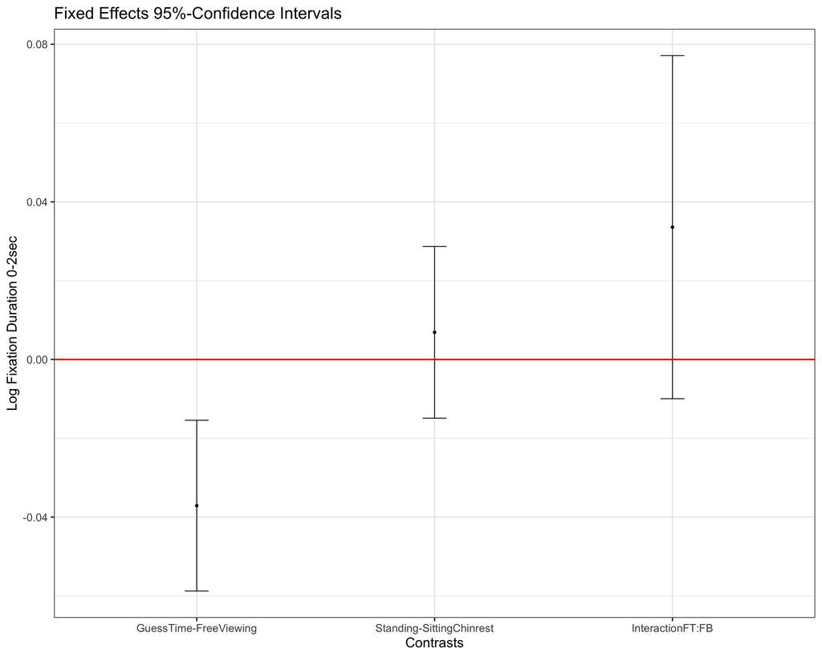

```r
# fixed effects
lmm.fix<-fixef(lmm)[-1]

# profiling
#p_lmm <- profile(lmm, which="beta_")
#confint(p_lmm)

# Wald
lmm.fixconf<-data.frame(M=fixef(lmm)[-1],
                        as.data.frame(confint(lmm,parm=c("(Intercept)","n.FT","n.FB","n.FAB"),method="Wald")[-1,]),
                        Contrast=c("GuessTime-FreeViewing", "Standing-SittingChinrest", "InteractionFT:FB"))

names(lmm.fixconf)<-c("M","min","max","Contrast")


p0<-ggplot(data=lmm.fixconf, aes(x=Contrast, y=M, ymin=min, ymax=max)) +
  geom_point()+geom_errorbar(width=.1)+geom_hline(yintercept=0, color='red', size=1)+
  scale_x_discrete(limits=lmm.fixconf$Contrast)+
  xlab("Contrasts")+
  ylab(labelDV)+
  theme_bw(base_size=18) +
  theme(legend.justification=c(1,0), legend.position=c(1,0),
        legend.background=element_rect(fill="white", color="black")) +
  ggtitle("Fixed Effects 95%-Confidence Intervals")
p0
```

## Visualize LMM partial effects (2)

```r
d <- fortify.merMod(lmm)

d$pe_DV <- remef(lmm, ran="all") # remove all random effects

tab_lmmse <- d %>%
             group_by(Factor) %>% # Compute M + SE
             summarize(N = n(), M = mean(pe_DV),
                       SD = sd(pe_DV), SE = SD/sqrt(N), CI=1.96*SE,
                       SD_res = sd(.resid), SE_res =SD_res/sqrt(N), CI_res=1.96*SE_res )

tab_lmmse
```

```
## # A tibble: 4 x 9
##   Factor                   N     M    SD     SE     CI SD_res SE_res CI_res
##   <fct>                <int> <dbl> <dbl>  <dbl>  <dbl>  <dbl>  <dbl>  <dbl>
## 1 FreeViewing_Sitting…  2066  5.43 0.527 0.0116 0.0227  0.527 0.0116 0.0227
## 2 FreeViewing_Standing  2074  5.42 0.526 0.0115 0.0226  0.526 0.0115 0.0226
## 3 GuessTime_SittingCh…  2265  5.38 0.493 0.0104 0.0203  0.493 0.0104 0.0203
## 4 GuessTime_Standing    2192  5.40 0.495 0.0106 0.0207  0.495 0.0106 0.0207
```

```r
tab_real <- d %>%
             group_by(Factor) %>% # Compute M + SE
             summarize(N = n(), M = mean(DV),
                       SD = sd(DV), SE = SD/sqrt(N), CI=1.96*SE)

tab_real
```

```
## # A tibble: 4 x 6
##   Factor                          N     M    SD     SE     CI
##   <fct>                       <int> <dbl> <dbl>  <dbl>  <dbl>
## 1 FreeViewing_SittingChinrest  2066  5.42 0.536 0.0118 0.0231
## 2 FreeViewing_Standing         2074  5.42 0.532 0.0117 0.0229
## 3 GuessTime_SittingChinrest    2265  5.37 0.502 0.0105 0.0207
## 4 GuessTime_Standing           2192  5.40 0.501 0.0107 0.0210
```

```r
d$DVfit<-fitted.values(lmm)

tab_model <- d %>%
             group_by(Factor) %>% # Compute M + SE
             summarize(N = n(), M = mean(DVfit),
                       SD = sd(DV), SE = SD/sqrt(N), CI=1.96*SE)

tab_model
```

```
## # A tibble: 4 x 6
##   Factor                          N     M    SD     SE     CI
##   <fct>                       <int> <dbl> <dbl>  <dbl>  <dbl>
## 1 FreeViewing_SittingChinrest  2066  5.42 0.536 0.0118 0.0231
## 2 FreeViewing_Standing         2074  5.42 0.532 0.0117 0.0229
## 3 GuessTime_SittingChinrest    2265  5.37 0.502 0.0105 0.0207
## 4 GuessTime_Standing           2192  5.40 0.501 0.0107 0.0210
```

## Standard errors - between-subjects (1)

How does partial-effect CI compare with traditional SEs? We start with a computation of **invalid** standard errors (SEs). Note that they are **invalid** because the computation assumes that all observations are independent. We know they are not because Factor is a within-subject and a within-item factor. (Of course, between-item standard errors computed this way would also be invalid.)

```r
tab_bsse <- d %>%
            group_by(VP, Factor) %>%
            summarise(DV = mean(DV)) %>%
            group_by(Factor) %>%
            summarise(N = n(), M = mean(DV), SD = sd(DV), SE = SD/sqrt(N), CI=1.96*SE)
tab_bsse
```

```
## # A tibble: 4 x 6
##   Factor                          N     M     SD     SE     CI
##   <fct>                       <int> <dbl>  <dbl>  <dbl>  <dbl>
## 1 FreeViewing_SittingChinrest    27  5.43 0.103  0.0199 0.0389
## 2 FreeViewing_Standing           27  5.43 0.0935 0.0180 0.0353
## 3 GuessTime_SittingChinrest      27  5.38 0.0966 0.0186 0.0364
## 4 GuessTime_Standing             27  5.41 0.0866 0.0167 0.0327
```

## Standard errors - between-image (1)

We compute **invalid** standard errors (SEs). Note that they are **invalid** because the computation assumes that all observations are independent. We know they are not because Factor is a within-subject and a within-item factor. (Of course, between-item standard errors computed this way would also be invalid.)

```r
tab_bise <- d %>%
            group_by(Img, Factor) %>%
            summarise(DV = mean(DV)) %>%
            group_by(Factor) %>%
            summarise(N = n(), M = mean(DV), SD = sd(DV), SE = SD/sqrt(N), CI=1.96*SE)
tab_bise
```

```
## # A tibble: 4 x 6
##   Factor                          N     M     SD     SE     CI
##   <fct>                       <int> <dbl>  <dbl>  <dbl>  <dbl>
## 1 FreeViewing_SittingChinrest    30  5.44 0.110  0.0201 0.0394
## 2 FreeViewing_Standing           30  5.42 0.0695 0.0127 0.0249
## 3 GuessTime_SittingChinrest      30  5.38 0.0751 0.0137 0.0269
## 4 GuessTime_Standing             30  5.40 0.0703 0.0128 0.0251
```

## Standard errors - within-subjects (2)

A more appropriate method for within-subject effects is to remove between-subject differences and compute the standard errors relative to each subject’s mean. These are so-called *within-subject* standard errors. We also apply a correction according to Morey (2008).

```r
d <- d %>%
               group_by(VP) %>%
               mutate(M_VP = mean(DV)) # compute subject means

d$DV_VP <- d$DV - d$M_VP + mean(d$M_VP)
# subtract subject means from their measures and ...
# ... add grand mean (i.e., mean of subjects' means)

k <- length(unique(d$Factor)) # n cells of design
mf <- sqrt(k/(k-1))                # Morey factor

tab_wsse <- d %>%
            group_by(VP, Factor) %>%
            summarise(DV = mean(DV_VP)) %>%
            group_by(Factor) %>%
            summarize(N = n(), M = mean(DV), SD = sd(DV),
                      SE = mf*sd(DV)/sqrt(N), CI=1.96*SE)
tab_wsse
```

```
## # A tibble: 4 x 6
##   Factor                          N     M     SD     SE     CI
##   <fct>                       <int> <dbl>  <dbl>  <dbl>  <dbl>
## 1 FreeViewing_SittingChinrest    27  5.43 0.0551 0.0123 0.0240
## 2 FreeViewing_Standing           27  5.43 0.0601 0.0134 0.0262
## 3 GuessTime_SittingChinrest      27  5.38 0.0538 0.0120 0.0234
## 4 GuessTime_Standing             27  5.40 0.0527 0.0117 0.0229
```

## Standard errors - within-images (3)

We can also compute standard errors relative to each item’s mean, that is a within-item standard error. Again, also with application of the correction factor (Morey, 2008).

```r
d <- d %>%
          group_by(Img) %>%
          mutate(M_Img = mean(DV)) # compute item means

d$DV_Img <- d$DV - d$M_Img + mean(d$M_Img)
# subtract item means from their measures and ...
# ... add grand mean (i.e., mean of items' means)

tab_wise <- d %>%
            group_by(Img, Factor) %>%
            summarise(DV = mean(DV_Img)) %>%
            group_by(Factor) %>%
            summarize(N = n(), M = mean(DV), SD = sd(DV),
                      SE = mf*sd(DV)/sqrt(N), CI=1.96*SE)
tab_wise
```

```
## # A tibble: 4 x 6
##   Factor                          N     M     SD     SE     CI
##   <fct>                       <int> <dbl>  <dbl>  <dbl>  <dbl>
## 1 FreeViewing_SittingChinrest    30  5.44 0.0849 0.0179 0.0351
## 2 FreeViewing_Standing           30  5.42 0.0505 0.0107 0.0209
## 3 GuessTime_SittingChinrest      30  5.38 0.0530 0.0112 0.0219
## 4 GuessTime_Standing             30  5.40 0.0484 0.0102 0.0200
```

Given the lack of independence of observations on the same item (clustering), within-item SEs are smaller than between-item SEs.

## Standard errors - within subjects and within images (4)

```r
d$DV_VP_Img <- d$DV - d$M_Img - d$M_VP + mean(d$M_Img) + mean(d$M_VP)
# subtract item means and subject means from their measures and ...
# ... add grand mean

tab_wsiseMF <- d %>%
            group_by(VP, Img, Factor) %>%
            summarise(DV = mean(DV_VP_Img)) %>%
            group_by(Factor) %>%
            summarize(N = n(), M = mean(DV), SD = sd(DV),
                      SE = mf*sd(DV)/sqrt(N), CI=1.96*SE)
tab_wsiseMF
```

```
## # A tibble: 4 x 6
##   Factor                          N     M    SD     SE     CI
##   <fct>                       <int> <dbl> <dbl>  <dbl>  <dbl>
## 1 FreeViewing_SittingChinrest   403  5.46 0.247 0.0142 0.0279
## 2 FreeViewing_Standing          401  5.44 0.253 0.0146 0.0286
## 3 GuessTime_SittingChinrest     405  5.39 0.204 0.0117 0.0229
## 4 GuessTime_Standing            403  5.42 0.197 0.0113 0.0222
```

```r
tab_wsise <- d %>%
            group_by(VP, Img, Factor) %>%
            summarise(DV = mean(DV_VP_Img)) %>%
            group_by(Factor) %>%
            summarize(N = n(), M = mean(DV), SD = sd(DV),
                      SE = sd(DV)/sqrt(N), CI=1.96*SE)
tab_wsise
```

```
## # A tibble: 4 x 6
##   Factor                          N     M    SD      SE     CI
##   <fct>                       <int> <dbl> <dbl>   <dbl>  <dbl>
## 1 FreeViewing_SittingChinrest   403  5.46 0.247 0.0123  0.0242
## 2 FreeViewing_Standing          401  5.44 0.253 0.0127  0.0248
## 3 GuessTime_SittingChinrest     405  5.39 0.204 0.0101  0.0199
## 4 GuessTime_Standing            403  5.42 0.197 0.00983 0.0193
```

## Combine results

```r
# combine results into one data frame
tab <- rbind( #cbind(tab_bsse[ , c(1,3,6)], Effects = "Between-subject"),
              #cbind(tab_bise[ , c(1,3,6)], Effects = "Between-image"),
              #cbind(tab_wsse[ , c(1,3,6)], Effects = "Within-subject"),
              #cbind(tab_wise[ , c(1,3,6)], Effects = "Within-item"),
              #cbind(tab_wsiseMF[,c(1,3,6)],Effects = "Within-subject & -item: Morey factor"),
              #cbind(tab_wsise[, c(1,3,6)], Effects = "Within-subject & -item"),
              cbind(tab_lmmse[, c(1,3,6)], Effects = "LMM partial effect"),
              cbind(tab_real[, c(1,3,6)], Effects =  "real means"),
              cbind(tab_model[, c(1,3,6)], Effects =  "Model fit"))
tab
```

```
##                         Factor        M         CI            Effects
## 1  FreeViewing_SittingChinrest 5.433330 0.02273188 LMM partial effect
## 2         FreeViewing_Standing 5.423429 0.02263514 LMM partial effect
## 3    GuessTime_SittingChinrest 5.379439 0.02032055 LMM partial effect
## 4           GuessTime_Standing 5.403120 0.02070770 LMM partial effect
## 5  FreeViewing_SittingChinrest 5.424182 0.02311999         real means
## 6         FreeViewing_Standing 5.422850 0.02289834         real means
## 7    GuessTime_SittingChinrest 5.374456 0.02066358         real means
## 8           GuessTime_Standing 5.400973 0.02099345         real means
## 9  FreeViewing_SittingChinrest 5.424182 0.02311999          Model fit
## 10        FreeViewing_Standing 5.422850 0.02289834          Model fit
## 11   GuessTime_SittingChinrest 5.374456 0.02066358          Model fit
## 12          GuessTime_Standing 5.400973 0.02099345          Model fit
```

## Graph

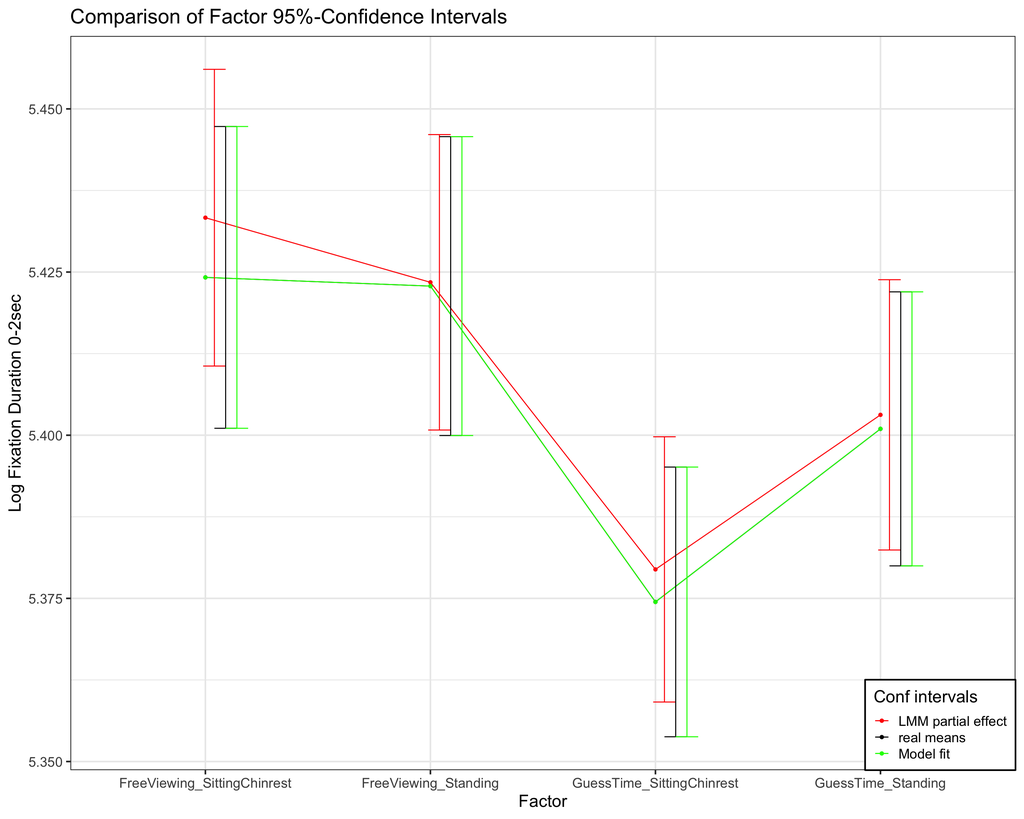

```r
# create figure
tab$FactorL <- as.numeric(tab$Factor) + as.numeric(tab$Effects)/20 - 0.01
p1 <- ggplot(data=tab, aes(x=Factor, y=M, ymin=M-CI, ymax=M+CI,
                            group=Effects, colour=Effects)) +
  #scale_color_manual(name="Conf intervals", values=c("darkblue","violet", "blue", "green", "black", "orange", "red","grey","darkgreen")) +
  scale_color_manual(name="Conf intervals", values=c( "red","black","green")) +
  geom_point() + geom_line() +
  geom_errorbar(width=.1, aes(x=FactorL)) +
  labs(x="Factor", y=labelDV) +
  #coord_cartesian(ylim=c(300, 500)) +
  theme_bw(base_size=18) +
  theme(legend.justification=c(1,0), legend.position=c(1,0),
        legend.background=element_rect(fill="white", color="black")) +
  ggtitle("Comparison of Factor 95%-Confidence Intervals")
p1
```